# Reproducible Data Analysis

2023-05-03

# 1. Introduction

Basketball is a team sport played on a rectangular court with two hoops or baskets, one at each end of the court. The objective of the game is to shoot a ball through the opposing team’s basket while preventing the other team from scoring in your own basket. Five players make up each team, and they are free to pass, dribble, or shoot the ball wherever on the floor. You can score points by putting the ball through the goal of the opposite team. A team can receive two points for a typical field goal, three points for a field goal made from beyond the three-point arc, and one point for each free throw they make. Basketball is played at all levels from youth leagues to professional leagues, and it is one of the most popular and widely watched sports in the world. The NBA (National Basketball Association) is the premier professional basketball league in the United States, while FIBA (International Basketball Federation) governs the sport internationally. (Logan, et al., 2023)

The National Basketball Association, or NBA, is a professional basketball league comprised of 30 teams across North America and is regarded as the top basketball league in the world. The NBA was founded in 1946 as the Basketball Association of America (BAA) and adopted its current name in 1949 after merging with the National Basketball League (NBL). The league is divided into two conferences (Eastern and Western) and each conference has three divisions with five teams in each division. The regular season consists of 82 games for each team, which runs from October to April, followed by the playoffs, where the top eight teams from each conference compete in a knockout tournament to determine the NBA champion. (NBA, 2019)

## 1.1. Positions in basketball

In basketball, there are five positions: point guard, shooting guard, small forward, power forward, and center. Each position has its own set of responsibilities and physical requirements. (NBA, 2019)

1. Point Guard (PG): Usually the smallest player on the team, the point guard is responsible for directing the team’s offense, bringing the ball up the court, and setting up plays. They are typically fast and agile, with good ball-handling and passing skills.
2. Shooting Guard (SG): The shooting guard is responsible for scoring points, both from outside the three-point line and by driving to the basket. They are typically taller than the point guard and have good shooting skills.
3. Small Forward (SF): The small forward is a versatile player who can play both inside and outside. They are typically taller than the shooting guard and have a good combination of size, speed, and shooting ability.
4. Power Forward (PF): The power forward is usually one of the tallest players on the team and is responsible for rebounding, defending the basket, and scoring points from inside the paint. They need to be strong and physical, with good jumping and dunking skills.
5. Center (C): The center is the tallest player on the team and is responsible for defending the basket, rebounding, and scoring points from inside the paint. They need to be strong and physical, with good jumping and dunking skills. They are often the team’s primary rim protector and help to anchor the team’s defense.

## 1.2. Introduction to dataset

There is a total of three dataset used in this project, which is described in data_description.txt.

[figure not shown]

Different stats of player are used to determine the best player in each position.

1. PG: AST, TOV, STL, `X3P.`, PTS
2. SG: `X3P.`, `FG.`, `eFG.`
3. SF: TRB, `FG.`, X3P, `eFG.`, AST, PF
4. PF: BLK, ORB, STL, `eFG.`
5. C: BLK, TRB, `X2P.`, `eFG.`, `FT.`

## 1.5. Libraries

1. tidyverse: The tidyverse is a collection of open source packages for the R programming language introduced by Hadley Wickham and his team that “share an underlying design philosophy, grammar, and data structures” of tidy data. (tidyverse, 2023)
2. dplyr: dplyr is a grammar of data manipulation, providing a consistent set of verbs that help you solve the most common data manipulation challenges: (tidyverse, 2023)
3. tidyr: tidyr is new package that makes it easy to “tidy” your data. Tidy data is data that’s easy to work with: it’s easy to munge (with dplyr), visualise (with ggplot2 or ggvis) and model (with R’s hundreds of modelling packages). The two most important properties of tidy data are: Each column is a variable. (tidyverse, 2023)
4. ggplot: ggplot2 is an open-source data visualization package for the statistical programming language R. ggplot2 is declaratively and efficient in creating data visualization based on The Grammar of Graphics. (tidyverse, 2023)
5. broom: The broom package takes the messy output of built-in functions in R, such as lm, nls, or t.test, and turns them into tidy tibbles. (Wickham, 2023)
6. naniar: naniar provides data structures and functions that facilitate the plotting of missing values and examination of imputations. This allows missing data dependencies to be explored with minimal deviation from the common work patterns of ‘ggplot2’ and tidy data. (Tierney, 2023)
7. caret: The caret package (short for Classification And REgression Training) contains functions to streamline the model training process for complex regression and classification problems. (Cran, 2023)

```r
#importing necessary libraries
library(tidyverse)
```

```r
library(dplyr)
library(tidyr)
library(ggplot2)
library(broom)
library(naniar)
library(caret)
```

## 1.6. Reading the datasets

Three datasets are read from the data folder, one containing the statistics of the players which includes numerous continuous variables including from Age to PTS and few categorical variable such as Player name, Position and Team they play on. The other two dataset has the name of the team and their payroll, and name of the player and their salaries respectively.

```r
#reading csv files individually for naming convention and better understanding data
salary <- read.csv('data/2018-19_nba_player-salaries.csv')
payroll <- read.csv('data/2019-20_nba_team-payroll.csv')
statistics <- read.csv('data/2018-19_nba_player-statistics.csv')

#since statistics has the player data, this will be the main focus of analysis
str(statistics)
```

```
## 'data.frame':    708 obs. of  29 variables:
##  $ player_name: chr  "Alex Abrines" "Quincy Acy" "Jaylen Adams" "Steven Adams" ...
##  $ Pos        : chr  "SG" "PF" "PG" "C" ...
##  $ Age        : int  25 28 22 25 21 21 25 33 21 23 ...
##  $ Tm         : chr  "OKC" "PHO" "ATL" "OKC" ...
##  $ G          : int  31 10 34 80 82 19 7 81 10 38 ...
##  $ GS         : int  2 0 1 80 28 3 0 81 1 2 ...
##  $ MP         : int  588 123 428 2669 1913 194 22 2687 120 416 ...
##  $ FG         : int  56 4 38 481 280 11 3 684 13 67 ...
##  $ FGA        : int  157 18 110 809 486 36 10 1319 39 178 ...
##  $ FG.        : num  0.357 0.222 0.345 0.595 0.576 0.306 0.3 0.519 0.333 0.376 ...
##  $ X3P        : int  41 2 25 0 3 6 0 10 3 32 ...
##  $ X3PA       : int  127 15 74 2 15 23 4 42 12 99 ...
##  $ X3P.       : num  0.323 0.133 0.338 0 0.2 0.261 0 0.238 0.25 0.323 ...
##  $ X2P        : int  15 2 13 481 277 5 3 674 10 35 ...
##  $ X2PA       : int  30 3 36 807 471 13 6 1277 27 79 ...
##  $ X2P.       : num  0.5 0.667 0.361 0.596 0.588 0.385 0.5 0.528 0.37 0.443 ...
##  $ eFG.       : num  0.487 0.278 0.459 0.595 0.579 0.389 0.3 0.522 0.372 0.466 ...
##  $ FT         : int  12 7 7 146 166 4 1 349 8 45 ...
##  $ FTA        : int  13 10 9 292 226 4 2 412 12 60 ...
##  $ FT.        : num  0.923 0.7 0.778 0.5 0.735 1 0.5 0.847 0.667 0.75 ...
##  $ ORB        : int  5 3 11 391 165 3 1 251 11 3 ...
##  $ DRB        : int  43 22 49 369 432 16 3 493 15 20 ...
##  $ TRB        : int  48 25 60 760 597 19 4 744 26 23 ...
##  $ AST        : int  20 8 65 124 184 5 6 194 13 25 ...
##  $ STL        : int  17 1 14 117 71 1 2 43 1 6 ...
##  $ BLK        : int  6 4 5 76 65 4 0 107 0 6 ...
##  $ TOV        : int  14 4 28 135 121 6 2 144 8 33 ...
##  $ PF         : int  53 24 45 204 203 13 4 179 7 47 ...
##  $ PTS        : int  165 17 108 1108 729 32 7 1727 37 211 ...
```

# 2. Data Cleaning

The data cleaning step includes removing of repetitive obseravations and imputing or removing Null variables.

```r
#count duplicates
n_occur <- data.frame(table(statistics$player_name))
n_occur[n_occur$Freq > 1,]
```

```
##                        Var1 Freq
## 7                Alec Burks    4
## 22          Andrew Harrison    4
## 31            Austin Rivers    3
## 32            Avery Bradley    3
## 38               BJ Johnson    3
## 40         Boban Marjanovic    3
## 41             Bobby Portis    3
## 49           Brandon Knight    3
## 56           Caleb Swanigan    3
## 57            Cameron Payne    3
## 71           Christian Wood    3
## 73                 CJ Miles    3
## 78             Corey Brewer    3
## 80             Courtney Lee    3
```

[output cut: 72 more lines]

```r
#keep the duplicates in a dataframe
n_occur <- statistics[statistics$player_name %in% n_occur$Var1[n_occur$Freq > 1],]
n_occur
```

```
##                 player_name   Pos Age  Tm  G GS   MP  FG  FGA   FG. X3P X3PA
## 16            Ryan Anderson    PF  30 MIA 10  0   44   2    9 0.222   2    6
## 17            Ryan Anderson    PF  30 PHO 15  8  278  19   60 0.317   7   34
## 18            Ryan Anderson    PF  30 TOT 25  8  322  21   69 0.304   9   40
## 25             Trevor Ariza    SF  33 PHO 26 26  884  86  227 0.379  50  139
## 26             Trevor Ariza    SF  33 WAS 43 43 1465 208  509 0.409  95  295
## 27             Trevor Ariza    SF  33 TOT 69 69 2349 294  736 0.399 145  434
## 32                Ron Baker    SG  25 WAS  4  0   45   0    4 0.000   0    4
## 33                Ron Baker    SG  25 TOT 15  0  152   4   20 0.200   1   13
## 34                Ron Baker    SG  25 NYK 11  0  107   4   16 0.250   1    9
## 39          Harrison Barnes    SF  26 SAC 28 28  949 141  310 0.455  53  130
## 40          Harrison Barnes    PF  26 DAL 49 49 1584 290  717 0.404 121  311
## 41          Harrison Barnes PF-SF  26 TOT 77 77 2533 431 1027 0.420 174  441
## 71            Avery Bradley    SG  28 MEM 14 14  442  87  188 0.463  28   73
## 72            Avery Bradley    SG  28 LAC 49 49 1463 161  420 0.383  58  172
```

[output cut: 780 more lines]

```r
# Filter the rows to keep only team= TOT
TOTs <- n_occur %>% filter(Tm == "TOT")

#subtract the duplicates from the original dataframe, this removes all the duplicates
statistics <- anti_join(statistics, n_occur, by = "player_name")

#add the TOTs dataframe which contains the duplicates where team was TOTAL
statistics <- rbind(statistics, TOTs)

statistics
```

```
##                  player_name   Pos Age  Tm  G GS   MP  FG  FGA   FG. X3P X3PA
## 1               Alex Abrines    SG  25 OKC 31  2  588  56  157 0.357  41  127
## 2                 Quincy Acy    PF  28 PHO 10  0  123   4   18 0.222   2   15
## 3               Jaylen Adams    PG  22 ATL 34  1  428  38  110 0.345  25   74
## 4               Steven Adams     C  25 OKC 80 80 2669 481  809 0.595   0    2
## 5                Bam Adebayo     C  21 MIA 82 28 1913 280  486 0.576   3   15
## 6                  Deng Adel    SF  21 CLE 19  3  194  11   36 0.306   6   23
## 7     DeVaughn Akoon-Purcell    SG  25 DEN  7  0   22   3   10 0.300   0    4
## 8          LaMarcus Aldridge     C  33 SAS 81 81 2687 684 1319 0.519  10   42
## 9               Rawle Alkins    SG  21 CHI 10  1  120  13   39 0.333   3   12
## 10             Grayson Allen    SG  23 UTA 38  2  416  67  178 0.376  32   99
## 11             Jarrett Allen     C  20 BRK 80 80 2096 335  568 0.590   6   45
## 12              Kadeem Allen    SG  26 NYK 19  1  416  65  141 0.461  17   36
## 13           Al-Farouq Aminu    PF  28 POR 81 81 2292 257  593 0.433  96  280
## 14           Justin Anderson    SF  25 ATL 48  4  463  64  157 0.408  24   77
```

[output cut: 1578 more lines]

```r
#filter(statistics, player_name %in% c("Ivica Zubac"))
```

There were numerous Null values in the ‘expected’ column of its corresponding variables. Those were tried to imputed using the formula provided in the code. However, there were observations where both the nominator and denominator were 0 which still gave Null values and thus were removed.

```r
#Checking for null values
na_count <-sapply(statistics, function(y) sum(length(which(is.na(y)))))
na_count
```

```
## player_name         Pos         Age          Tm           G          GS
##           0           0           0           0           0           0
##          MP          FG         FGA         FG.         X3P        X3PA
##           0           0           0           4           0           0
##        X3P.         X2P        X2PA        X2P.        eFG.          FT
##          36           0           0          10           4           0
##         FTA         FT.         ORB         DRB         TRB         AST
##           0          27           0           0           0           0
##         STL         BLK         TOV          PF         PTS
##           0           0           0           0           0
```

```r
# Define columns to impute and their corresponding denominator columns
columns_to_impute <- c("FG.", "X3P.", "X2P.", "FT.")
nominator_columns <- c("FG", "X3P",  "X2P", "FT")
denominator_columns <- c("FGA", "X3PA", "X2PA", "FTA" )

# Iterate through each column and impute NA values using the relative formula
for (i in seq_along(columns_to_impute)) {
  column <- columns_to_impute[i]
  nominator_column <- nominator_columns[i]
  denominator_column <- denominator_columns[i]

  na_index <- which(is.na(statistics[[column]]))
  statistics <- statistics[-na_index, ]

  statistics[[column]] <- ifelse(is.na(statistics[[column]]),
                                  statistics[[denominator_column]] / statistics[[denominator_column]],
                                  statistics[[column]])

  # Checking for null values
  na_count <-sapply(statistics, function(y) sum(length(which(is.na(y)))))
  #cat(sprintf("Null count after imputing column %s: %d\n", column, na_count))
}

na_count <-sapply(statistics, function(y) sum(length(which(is.na(y)))))
na_count
```

```
## player_name         Pos         Age          Tm           G          GS
##           0           0           0           0           0           0
##          MP          FG         FGA         FG.         X3P        X3PA
##           0           0           0           0           0           0
##        X3P.         X2P        X2PA        X2P.        eFG.          FT
##           0           0           0           0           0           0
##         FTA         FT.         ORB         DRB         TRB         AST
##           0           0           0           0           0           0
##         STL         BLK         TOV          PF         PTS
##           0           0           0           0           0
```

#3. Exploratory Data Analysis

Only players who have played more than 10 games are used in the analysis to determine the consistency of performance. The continuous variables are tested against each other to find outliers. But given the data is of players who have performed in games throughout the season, outliers are not removed as it may contain data of players having exceptionally well or below par season.

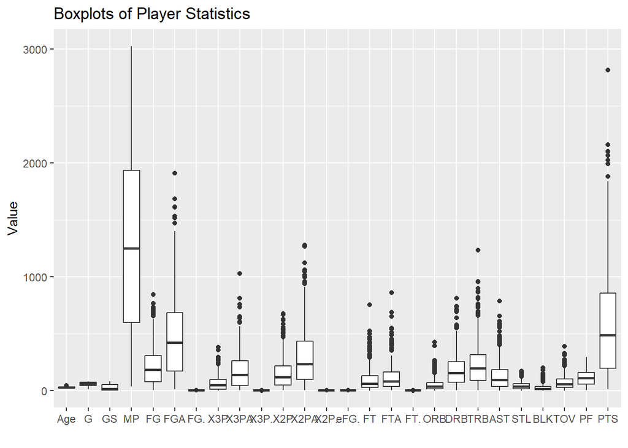

```r
#Finding outliers
# Select columns with relevant values
numeric_cols <- c("Age", "G", "GS", "MP", "FG", "FGA", "FG.","X3P", "X3PA", "X3P.", "X2P", "X2PA", "X2P.", "eFG.", "FT", "FTA", "FT.", "ORB", "DRB", "TRB", "AST", "STL", "BLK", "TOV", "PF", "PTS")

# Filter for players who have played at least 10 games
player_stats_filtered <- statistics[statistics$G >= 10,]

# Create a boxplot for each column
boxplot_data1 <- stack(player_stats_filtered[numeric_cols])
ggplot(boxplot_data1, aes(x = ind, y = values)) +
  geom_boxplot() +
  xlab("") +
  ylab("Value") +
  ggtitle("Boxplots of Player Statistics")
```

Boxplot to find which position of play score more points on average.

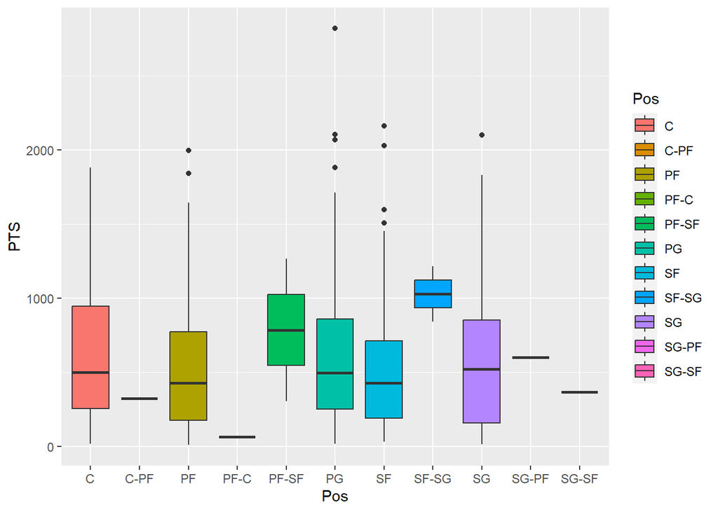

```r
# difference in points scored by position
ggplot(data = player_stats_filtered, aes(x = Pos, y = PTS, fill = Pos)) +
  geom_boxplot()
```

```r
# Compute the number of outliers for each column
outliers <- sapply(player_stats_filtered[numeric_cols], function(x) {
  q1 <- quantile(x, 0.25)
  q3 <- quantile(x, 0.75)
  iqr <- q3 - q1
  sum(x < q1 - 1.5*iqr | x > q3 + 1.5*iqr, na.rm = TRUE)
})

# Display the number of outliers for each column
outliers
```

```
##  Age    G   GS   MP   FG  FGA  FG.  X3P X3PA X3P.  X2P X2PA X2P. eFG.   FT  FTA
##    2    0    0    0   13    8   15    9   11   45   19   14   14   18   27   33
##  FT.  ORB  DRB  TRB  AST  STL  BLK  TOV   PF  PTS
##    9   33   10   19   29   10   26   17    0    9
```

```r
#Outliers is not removed because if contains data of player having exceptional season or sub-par season
```

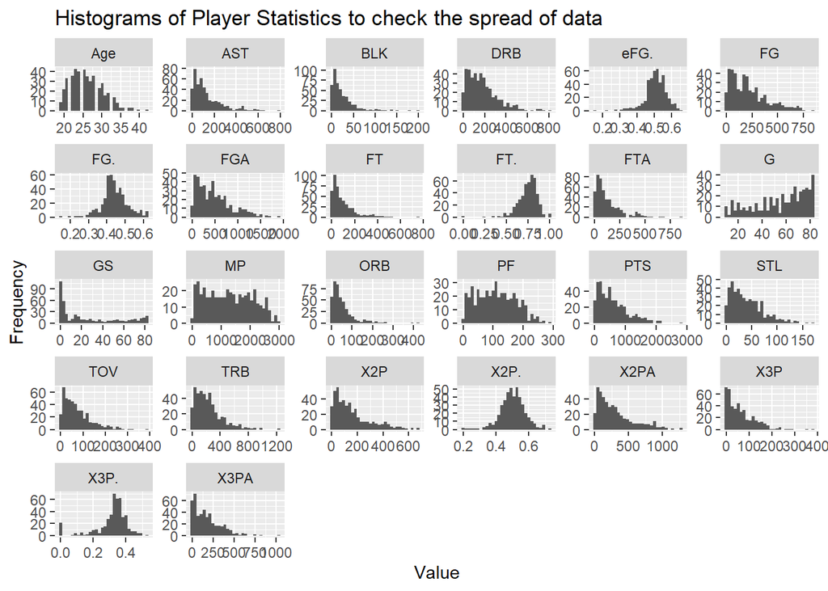

```r
#distribution of variable
player_stats_filtered %>%
  select(numeric_cols) %>%
  pivot_longer(everything(), names_to = "variable", values_to = "value") %>%
  ggplot(aes(x = value)) +
  geom_histogram() +
  facet_wrap(~variable, scales = "free") +
  xlab("Value") +
  ylab("Frequency") +
  ggtitle("Histograms of Player Statistics to check the spread of data")
```

Pairwise Complete Obs means is used to find the correlation between numeric variables which are used to computed for each variable using all non-missing values, and co-variances or correlations for each pair of variables are computed using observations with no missing data for that pair.(tibco, 2015) However, contradictory to the finding, the linear model in purposed to development uses PTS which in-terms is highly correlated to many statistics and thus the highly correlated variables are not removed. However, PTS is the only variable used among the highly correlated variables.

```r
cor_matrix <- cor(player_stats_filtered[numeric_cols], use="pairwise.complete.obs")
cor_matrix
```

```
##               Age          G         GS         MP         FG        FGA
## Age   1.000000000 0.09602953 0.02382369 0.08728836 0.04475346 0.05382854
## G     0.096029529 1.00000000 0.59154529 0.87292455 0.71818178 0.72224017
## GS    0.023823689 0.59154529 1.00000000 0.83666217 0.79323393 0.78845497
## MP    0.087288362 0.87292455 0.83666217 1.00000000 0.90485479 0.91492823
## FG    0.044753456 0.71818178 0.79323393 0.90485479 1.00000000 0.98582768
## FGA   0.053828540 0.72224017 0.78845497 0.91492823 0.98582768 1.00000000
## FG.   0.040864423 0.38791783 0.26595745 0.32217575 0.37898193 0.26945767
## X3P   0.147424911 0.59243039 0.60064957 0.73556456 0.69255130 0.76960078
## X3PA  0.135999444 0.60734134 0.60829884 0.75389054 0.70949554 0.79186123
## X3P.  0.061545105 0.18410917 0.17952394 0.23777914 0.18307364 0.22908166
## X2P  -0.007362841 0.64220996 0.73234404 0.81378944 0.95096464 0.90024254
## X2PA -0.006393477 0.64985709 0.74250311 0.83259075 0.95923714 0.92942005
## X2P.  0.049173944 0.30272141 0.17937127 0.23391304 0.24946407 0.16498447
## eFG.  0.125457525 0.43314482 0.27736447 0.36910902 0.35001968 0.28027640
## FT    0.050435737 0.55100700 0.66535490 0.74638377 0.88412576 0.87445983
## FTA   0.032743670 0.56260937 0.66890743 0.75278084 0.88816994 0.86856951
## FT.   0.175146014 0.25506476 0.21558287 0.28344965 0.26540455 0.30020095
## ORB  -0.019301576 0.50834681 0.49563901 0.53373058 0.56263821 0.46761739
## DRB   0.055286897 0.68486635 0.71607634 0.79464208 0.80760469 0.75820541
## TRB   0.035983532 0.66495810 0.68473976 0.75509023 0.77333229 0.70825485
## AST   0.117324346 0.55584471 0.64806207 0.73585744 0.74960382 0.77124723
## STL   0.073093923 0.69614798 0.73599114 0.84396739 0.75834286 0.77285804
## BLK   0.004053438 0.48041545 0.53012093 0.52727239 0.53961614 0.46606358
## TOV   0.030082992 0.63758698 0.73261078 0.82504444 0.89817647 0.89945109
## PF    0.041841295 0.82816682 0.72074821 0.86823382 0.75990188 0.73889796
## PTS   0.061134231 0.70725287 0.78614322 0.90045024 0.99232760 0.98966383
##              FG.          X3P         X3PA        X3P.          X2P
## Age   0.04086442  0.147424911  0.135999444  0.06154511 -0.007362841
## G     0.38791783  0.592430392  0.607341337  0.18410917  0.642209963
## GS    0.26595745  0.600649572  0.608298841  0.17952394  0.732344044
## MP    0.32217575  0.735564565  0.753890543  0.23777914  0.813789439
## FG    0.37898193  0.692551303  0.709495537  0.18307364  0.950964639
## FGA   0.26945767  0.769600780  0.791861228  0.22908166  0.900242545
## FG.   1.00000000 -0.042569124 -0.061598065 -0.07913692  0.491186977
## X3P  -0.04256912  1.000000000  0.990739117  0.45900571  0.435472759
## X3PA -0.06159807  0.990739117  1.000000000  0.42690312  0.460588378
## X3P. -0.07913692  0.459005715  0.426903122  1.00000000  0.031652266
## X2P   0.49118698  0.435472759  0.460588378  0.03165227  1.000000000
## X2PA  0.41659402  0.484863888  0.510608635  0.06456538  0.989145993
```

[output cut: 80 more lines]

```
## X2PA 0.88135715 0.7187594 0.93353210
## X2P. 0.17442550 0.3325562 0.21966280
## eFG. 0.23216756 0.4209320 0.33159575
## FT   0.86737866 0.6300344 0.91735277
## FTA  0.88066805 0.6630610 0.91141711
## FT.  0.20268304 0.1527357 0.29867248
## ORB  0.47547552 0.6765841 0.50984255
## DRB  0.75310340 0.8099402 0.78510539
## TRB  0.70671646 0.8085097 0.74090088
## AST  0.88158582 0.5616300 0.75941074
## STL  0.76298846 0.7392182 0.75690310
## BLK  0.44822876 0.6397058 0.50428924
## TOV  1.00000000 0.7305923 0.90391899
## PF   0.73059232 1.0000000 0.74383144
## PTS  0.90391899 0.7438314 1.00000000
```

```r
# Convert the dataset to a matrix and remove non-numeric columns
player_stats_matrix <- as.matrix(player_stats_filtered[, numeric_cols])

# Use the findCorrelation function to find highly correlated variables
highly_correlated <- findCorrelation(cor_matrix, cutoff = 0.9, names = TRUE, exact = ncol(cor_matrix) < 100)
highly_correlated
```

```
## [1] "FG"   "PTS"  "MP"   "FGA"  "X2P"  "DRB"  "FTA"  "X3PA"
```

```r
#highly_correlated columns are not removed as data provided by columns such as PTS and MP are very important factor of the game
```

# 4. Data Modelling

Splitting the statistics dataset (player_stat_filter which contains the data of player who has more than 10 games played) to train and test.

```r
set.seed(123) # for reproducibility
train_index <- createDataPartition(player_stats_filtered$PTS, p = 0.8, list = FALSE)
train_data <- player_stats_filtered[train_index, ]
test_data <- player_stats_filtered[-train_index, ]
```

## 4.1 Linear Regression

A linear regression model is created to predict PTS scored in respect to expected 2 points, expected 3 points, expected field goals, assists and offensive rebounds.

```r
#create linear regression model to
# Select variables of interest
model_shooter <- train_data %>%
  select(ORB, `FG.`,`X2P.`, `X3P.`, `eFG.`, AST, PTS)

# Fit a linear model
model_shooter <- lm(PTS ~ ORB+`FG.`+`X2P.`+`X3P.`+`eFG.`+ AST, data = train_data)

tidy(model_shooter, conf.int = TRUE)
```

```
## # A tibble: 7 × 7
##   term        estimate std.error statistic  p.value conf.low conf.high
##   <chr>          <dbl>     <dbl>     <dbl>    <dbl>    <dbl>     <dbl>
## 1 (Intercept)  -305.     118.      -2.58   1.04e- 2  -538.      -72.0
## 2 ORB             3.40     0.333   10.2    1.48e-21     2.74      4.05
## 3 FG.          -718.     572.      -1.26   2.10e- 1 -1844.      407.
## 4 X2P.           24.1    330.       0.0732 9.42e- 1  -624.      672.
## 5 X3P.          695.     209.       3.32   9.92e- 4   283.     1106.
## 6 eFG.          962.     594.       1.62   1.06e- 1  -206.     2130.
## 7 AST             2.34     0.111   21.1    1.36e-64     2.12      2.55
```

The intercept coefficient indicates that certain amount is added or subtracted to the interpreted variable when all other variables remain zero or constant.

```r
# Print the summary of the model
summary(model_shooter)
```

```
##
## Call:
## lm(formula = PTS ~ ORB + FG. + X2P. + X3P. + eFG. + AST, data = train_data)
##
## Residuals:
##     Min      1Q  Median      3Q     Max
## -847.11 -141.42  -29.52  117.67 1058.38
##
## Coefficients:
##              Estimate Std. Error t value Pr(>|t|)
## (Intercept) -304.7692   118.3373  -2.575 0.010419 *
## ORB            3.3962     0.3331  10.195  < 2e-16 ***
## FG.         -718.4447   572.2588  -1.255 0.210147
## X2P.          24.1262   329.6362   0.073 0.941696
## X3P.         694.8392   209.2401   3.321 0.000992 ***
## eFG.         962.2381   593.9930   1.620 0.106139
## AST            2.3358     0.1105  21.133  < 2e-16 ***
## ---
## Signif. codes:  0 '***' 0.001 '**' 0.01 '*' 0.05 '.' 0.1 ' ' 1
##
## Residual standard error: 263 on 352 degrees of freedom
## Multiple R-squared:  0.7197, Adjusted R-squared:  0.7149
## F-statistic: 150.7 on 6 and 352 DF,  p-value: < 2.2e-16
```

The coefficients column shows the estimated regression coefficients for each predictor variable. A positive estimate for ORB, X2P., to AST suggests that an increase in those variables is associated with an increase in points scored. A negative estimate for FG. indicates that increase in estimated Field goal is related to decrease in points scored.

### 4.1.1. Checking the independence of model

The durbinWatsonTest.

```r
#check independence
car::durbinWatsonTest(model_shooter)
```

```
##  lag Autocorrelation D-W Statistic p-value
##    1     0.008767291      1.980577   0.812
##  Alternative hypothesis: rho != 0
```

### 4.1.2. Homoscedasticity

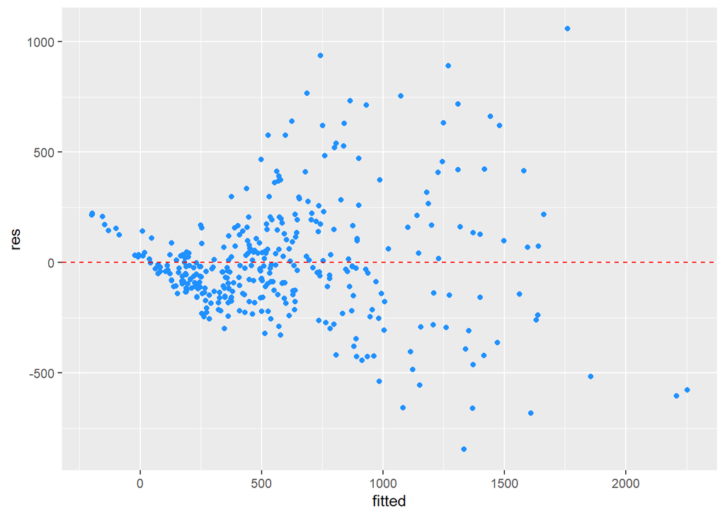

```r
res <- residuals(model_shooter)
fitted <- predict(model_shooter)

ggplot(data = NULL, aes(x = fitted, y = res)) +
  geom_point(colour = "dodgerblue") +
  geom_hline(yintercept = 0, colour = "red", linetype = "dashed")
```

When the error term—the “noise” or random disturbance in the relationship between the independent variables and the dependent variable—is the same at all independent variable values, the condition is referred to as homoscedastic. The plot suggests sign of Heteroskedasticity which implies that the finding of regression mode may be invalid. (scribbr, 2023)

###4.1.3. Normality

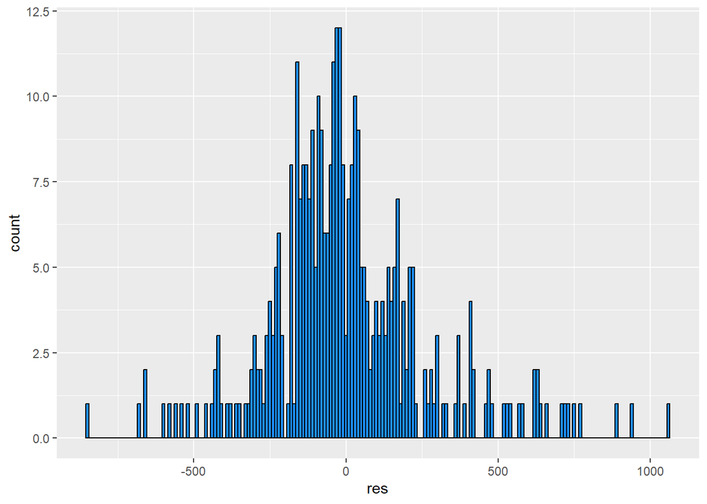

```r
ggplot(data = NULL, aes(x = res)) +
  geom_histogram(colour = "black", fill = "dodgerblue", binwidth = 10)
```

The normality assumption means that the collected data follows a normal distribution, which is essential for assumption. The histogram looks fairly normal. (statisticssolutions, 2023)

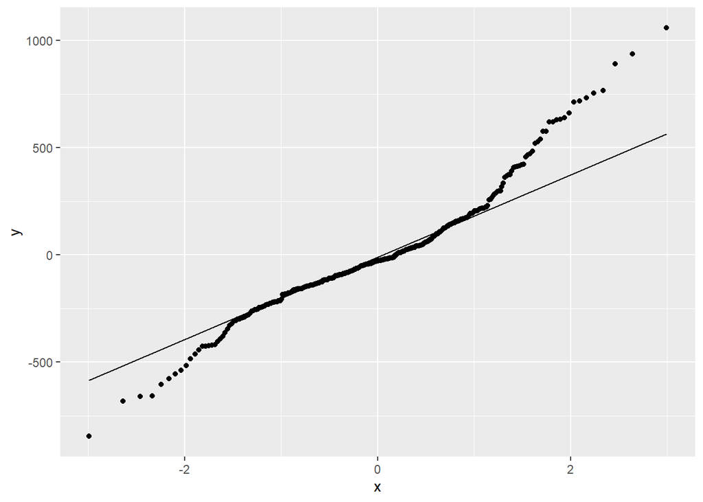

```r
ggplot(data = NULL, aes(sample = res)) +
  stat_qq() + stat_qq_line()
```

There are longer tails at both ends, this requires transformation of data.

### 4.1.4. Linearity

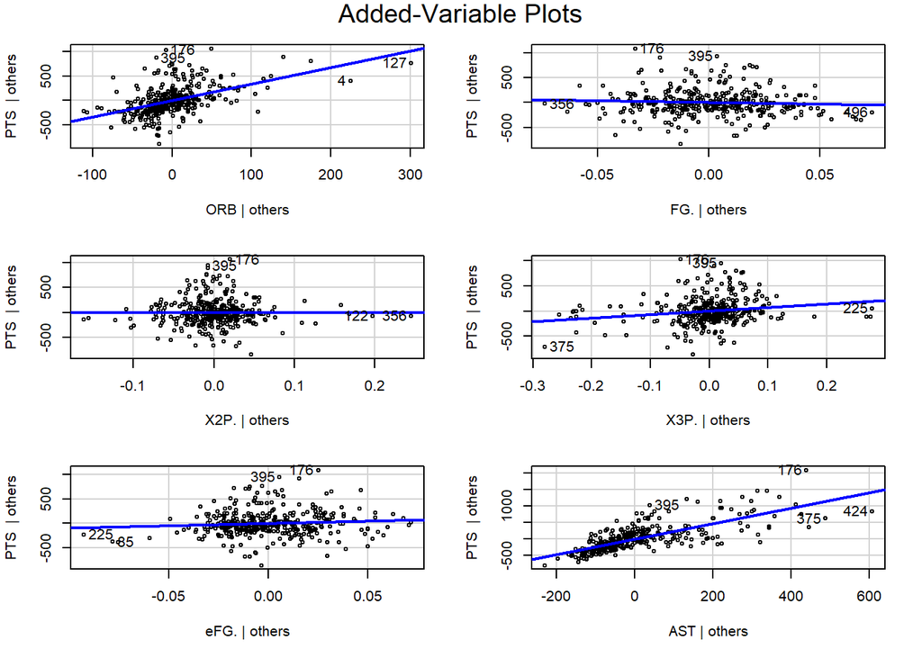

```r
car::avPlots(model_shooter)
```

## 4.2 Model prediction

Using the model to predict top 5 most consistent shooter.

```r
# predict PTS using the linear model
predicted <- predict(model_shooter, newdata = test_data)

# get the index of the player with the highest predicted PTS
index_highest_pts <- which.max(predicted)

# get the name of the player with the highest predicted PTS
player_stats_filtered[index_highest_pts, "player_name"]
```

```
## [1] "Jevon Carter"
```

```r
# create a new data frame with predicted values
df_pred <- player_stats_filtered %>%
  select(player_name, Pos, Tm, ORB, `FG.`,`X2P.`, `X3P.`, `eFG.`, AST, PTS) %>%
  mutate(pred_PTS = predict(model_shooter, .))

# sort by predicted PTS and select top 5
top5 <- df_pred %>%
  arrange(desc(pred_PTS)) %>%
  top_n(5, pred_PTS)

# print the top 5 players
top5
```

```
##         player_name Pos  Tm ORB   FG.  X2P.  X3P.  eFG. AST  PTS pred_PTS
## 1 Russell Westbrook  PG OKC 109 0.428 0.481 0.290 0.468 784 1675 2252.630
## 2      Nikola Jokic   C DEN 228 0.511 0.569 0.307 0.545 580 1604 2208.670
## 3       Ben Simmons  PG PHI 172 0.563 0.566 0.000 0.563 610 1337 1855.130
## 4        Trae Young  PG ATL  64 0.418 0.477 0.324 0.480 653 1549 1836.070
## 5      James Harden  PG HOU  66 0.442 0.528 0.368 0.541 586 2818 1759.621
```

The top 5 most consistent scorers as predicted by the model suggests those players whom most play as Point Guard.

# 5. Analysing top players in each position

There are 5 positions in a basketball court with each having their own responsibility. To find the best player in each of the different position, different stats are analysed and figured corresponding to their role in the game. (BUCKLEY, 2022) The players are ranked by their mean Z score. The number of standard deviations a data point deviates from the distribution’s mean is expressed as a z-score (also known as a standard score). A score is subtracted from the population mean, and the result is divided by the population standard deviation. The calculated value shows how many standard deviations the unique score deviates from the mean.

```r
#getting the abbreviations of player positions as well as knowing what player who play in more position is denoted as
unique_positions <- unique(statistics$Pos)
print(unique_positions)
```

```
##  [1] "SG"    "PF"    "PG"    "C"     "SF"    "PF-SF" "SF-SG" "SG-PF" "C-PF"
## [10] "SG-SF" "PF-C"
```

## 5.1. Top players in respect to their position

### 5.1.1 Point Guard

Ability to assist, turnover, steal, and score 3 points is what makes a top point guard. Z score measurement is performed based on these variables to produce the top point guards.

```r
#finding the top Point Guard using Z score
top_point_guards <- player_stats_filtered %>%
  filter(Pos=="PG") %>%
  select(player_name, Tm, AST, TOV, STL, `X3P.`, PTS) %>%
  mutate(across(-c(player_name, Tm), scale, center = TRUE, scale = TRUE)) %>%
  rowwise() %>%
  mutate(player_mean_zscore = mean(c_across(-c(player_name, Tm)), na.rm = TRUE)) %>%
  ungroup() %>%
  arrange(desc(player_mean_zscore)) %>%
  top_n(10, player_mean_zscore)
top_point_guards
```

```
## # A tibble: 10 × 8
##    player_name Tm    AST[,1] TOV[,1] STL[,1] X3P.[,1] PTS[,1] player_mean_zscore
##    <chr>       <chr>   <dbl>   <dbl>   <dbl>    <dbl>   <dbl>              <dbl>
##  1 James Hard… HOU     2.06    3.92    3.04    0.536     4.03               2.72
##  2 Russell We… OKC     3.23    3.09    2.59   -0.438     1.92               2.08
##  3 De'Aaron F… SAC     2.08    1.78    2.34    0.573     1.41               1.64
##  4 D'Angelo R… BRK     1.93    2.13    1.41    0.548     1.99               1.60
##  5 Damian Lil… POR     1.85    1.58    1.07    0.548     2.64               1.54
##  6 Trae Young  ATL     2.46    2.86    0.616  -0.0133    1.69               1.52
##  7 Kemba Walk… CHO     1.46    1.57    1.46    0.386     2.71               1.52
##  8 Stephen Cu… GSW     0.734   1.31    1.18    1.40      2.30               1.38
##  9 Kyrie Irvi… BOS     1.34    1.05    1.49    0.948     1.77               1.32
## 10 Eric Bleds… MIL     1.14    0.953   1.86    0.0491    1.12               1.02
```

Ranking the output to scale the difference.

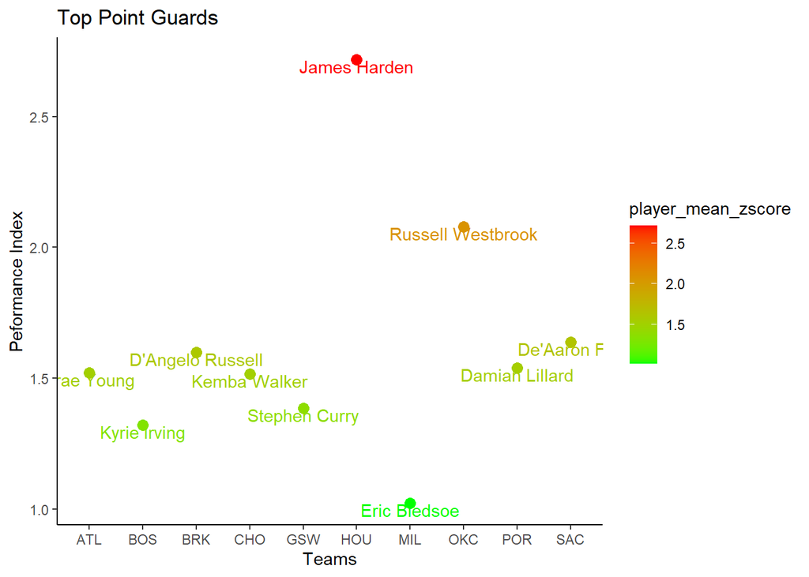

```r
ggplot(top_point_guards, aes(x = Tm, y = player_mean_zscore, color = player_mean_zscore)) +
  geom_point(size = 3) +
  geom_text(aes(label = player_name), vjust = 1) +
  scale_color_gradient(low = "green", high = "red") +
  ggtitle("Top Point Guards") +
  xlab("Teams")+
  ylab("Peformance Index")+
  theme_classic()
```

### 5.1.2.Shooting Guard

Ability to effectively score 2, 3 points, and field goals is what makes a top shooting guard. Z score measurement is performed based on these variables to produce the top shooting guards.

```r
#top shooting guard
# Filter for shooting guards
top_shooting_guards <- player_stats_filtered %>%
  filter(Pos %in% c("SG", "SG-PF", "SG-SF")) %>%
  select(player_name, Tm, `X3P.`, `FG.`, `eFG.`) %>%
  mutate(across(-c(player_name, Tm), scale, center = TRUE, scale = TRUE)) %>%
  rowwise() %>%
  mutate(player_mean_zscore = mean(c_across(-c(player_name, Tm)), na.rm = TRUE)) %>%
  ungroup() %>%
  arrange(desc(player_mean_zscore)) %>%
  top_n(10, player_mean_zscore)

top_shooting_guards
```

```
## # A tibble: 10 × 6
##    player_name     Tm    X3P.[,1] FG.[,1] eFG.[,1] player_mean_zscore
##    <chr>           <chr>    <dbl>   <dbl>    <dbl>              <dbl>
##  1 Joe Harris      BRK      1.93    1.79     2.08                1.93
##  2 Danny Green     TOR      1.66    1.06     2.08                1.60
##  3 Malcolm Brogdon MIL      1.25    1.89     1.32                1.48
##  4 Seth Curry      POR      1.59    0.876    1.35                1.27
##  5 E'Twaun Moore   NOP      1.33    1.39     0.958               1.23
##  6 Malik Beasley   DEN      0.906   1.25     1.46                1.21
##  7 Ryan Broekhoff  DAL      1.01    0.794    1.77                1.19
##  8 Dwayne Bacon    CHO      1.40    1.27     0.893               1.19
##  9 Norman Powell   TOR      0.877   1.43     1.20                1.17
## 10 Bryn Forbes     SAS      1.25    0.876    1.20                1.11
```

Ranking the output to scale the difference.

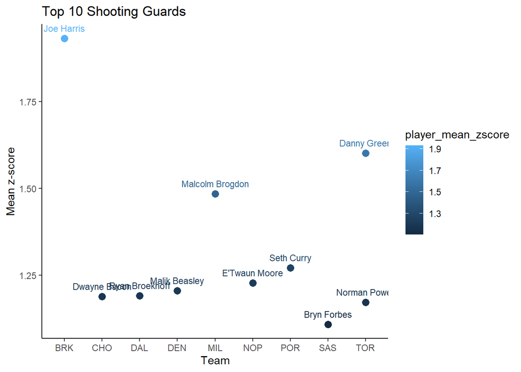

```r
ggplot(top_shooting_guards, aes(x = Tm, y = player_mean_zscore, color = player_mean_zscore)) +
  geom_point(size=3) +
  geom_text(aes(label = player_name), vjust = -1, size = 3) +
  labs(x = "Team", y = "Mean z-score") +
  ggtitle("Top 10 Shooting Guards") +
  theme_classic()
```

### 5.1.3. Small Forward

```r
#top  10 small forward
top_small_forwards <- player_stats_filtered %>%
  filter(Pos %in% c("SF", "SF-SG")) %>%
  select(player_name, Tm, TRB, `FG.`, X3P, `eFG.`, AST, PF) %>%
  mutate(across(-c(player_name, Tm), scale, center = TRUE, scale = TRUE)) %>%
  rowwise() %>%
  mutate(player_mean_zscore = mean(c_across(-c(player_name, Tm)), na.rm = TRUE)) %>%
  ungroup() %>%
  arrange(desc(player_mean_zscore)) %>%
  top_n(10, player_mean_zscore)

top_small_forwards
```

```
## # A tibble: 10 × 9
##    player_name      Tm    TRB[,1] FG.[,1] X3P[,1] eFG.[,1] AST[,1] PF[,1]
##    <chr>            <chr>   <dbl>   <dbl>   <dbl>    <dbl>   <dbl>  <dbl>
##  1 Paul George      OKC     3.00   0.0307   4.14     0.318   2.18   2.04
##  2 Kevin Durant     GSW     2.06   1.64     1.31     1.09    3.57   0.966
##  3 LeBron James     LAL     1.82   1.43     0.837    0.890   3.54  -0.141
##  4 Khris Middleton  MIL     1.80   0.0890   2.08     0.133   2.31   1.27
##  5 Bojan Bogdanovic IND     0.872  1.18     1.80     1.17    0.601  0.657
##  6 Danilo Gallinari LAC     1.48   0.516    1.75     0.779   0.772  0.494
##  7 Nicolas Batum    CHO     1.28   0.264    0.928    0.761   1.46   0.694
##  8 Kawhi Leonard    TOR     1.64   1.16     0.855    0.632   0.982 -0.268
##  9 Jayson Tatum     BOS     1.91   0.264    0.928   -0.107   0.671  1.20
## 10 Cedi Osman       CLE     1.05  -0.183    1.18    -0.144   0.942  1.69
## # ℹ 1 more variable: player_mean_zscore <dbl>
```

Ranking the players to scale the difference.

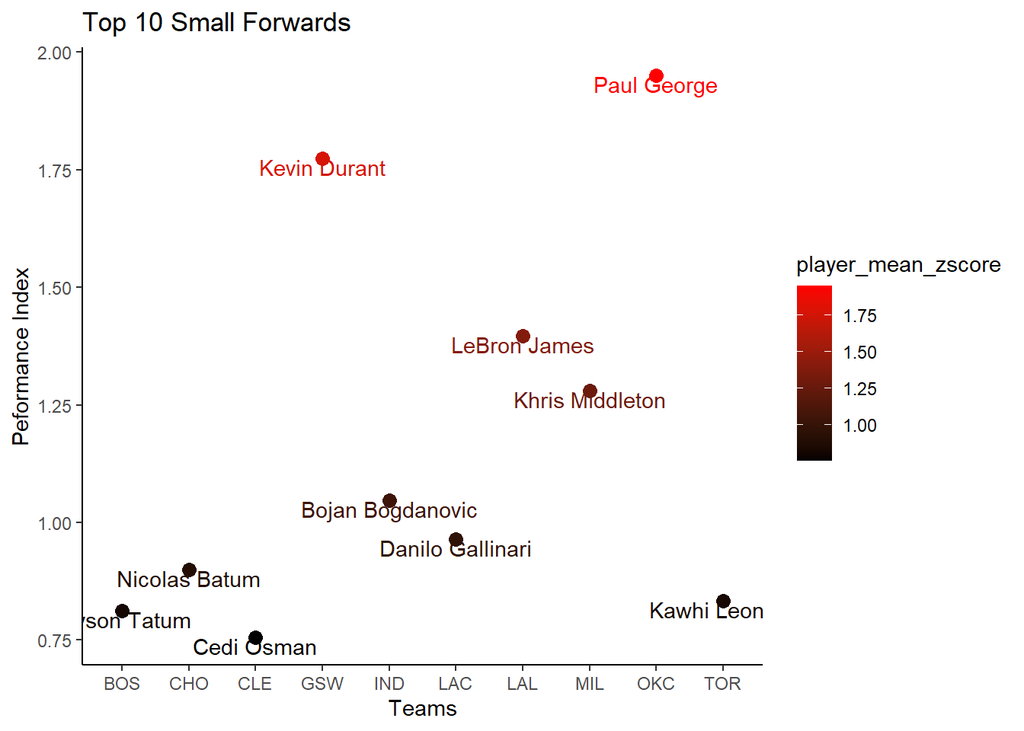

```r
ggplot(top_small_forwards, aes(x = Tm, y = player_mean_zscore, color = player_mean_zscore)) +
  geom_point(size = 3) +
  geom_text(aes(label = player_name), vjust = 1) +
  scale_color_gradient(low = "black", high = "red") +
  ggtitle("Top 10 Small Forwards") +
  xlab("Teams")+
  ylab("Peformance Index")+
  theme_classic()
```

### 5.1.4. Power Forwards

Ability to block, get offensive rebounds and steal is what makes a top power forward. Z score measurement is performed based on these variables to produce the top power forwards.

```r
#top power forwards
top_power_forwards <- player_stats_filtered %>%
  filter(Pos %in% c("PF", "PF-SF", "PF-C")) %>%
  select(player_name, Tm, BLK, ORB, STL, `eFG.`) %>%
  mutate(across(-c(player_name, Tm), scale, center = TRUE, scale = TRUE)) %>%
  rowwise() %>%
  mutate(player_mean_zscore = mean(c_across(-c(player_name, Tm)), na.rm = TRUE)) %>%
  ungroup() %>%
  arrange(desc(player_mean_zscore)) %>%
  top_n(10, player_mean_zscore)

top_power_forwards
```

```
## # A tibble: 10 × 7
##    player_name         Tm    BLK[,1] ORB[,1] STL[,1] eFG.[,1] player_mean_zscore
##    <chr>               <chr>   <dbl>   <dbl>   <dbl>    <dbl>              <dbl>
##  1 Giannis Antetokoun… MIL     3.65    2.10    2.21     1.26                2.30
##  2 Thaddeus Young      IND     0.431   2.79    3.35     0.623               1.80
##  3 PJ Tucker           HOU     0.561   1.30    3.68     0.288               1.46
##  4 Jerami Grant        OKC     3.21    0.778   1.06     0.776               1.46
##  5 Paul Millsap        DEN     1.21    1.97    1.87     0.181               1.31
##  6 Pascal Siakam       TOR     1.13    1.37    1.50     1.14                1.28
##  7 John Collins        ATL     0.561   3.36   -0.377    1.17                1.18
##  8 Jonathan Isaac      ORL     3.13    0.841   0.988   -0.262               1.17
##  9 Taj Gibson          MIN     0.561   2.37    0.767    0.913               1.15
## 10 Julius Randle       NOP     0.822   2.16    0.730    0.593               1.08
```

Ranking the players to scale the difference.

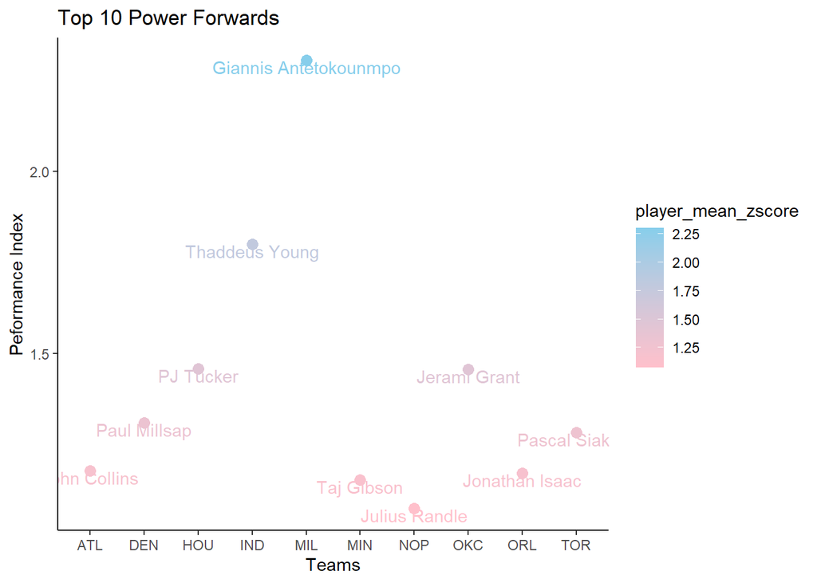

```r
ggplot(top_power_forwards, aes(x = Tm, y = player_mean_zscore, color = player_mean_zscore)) +
  geom_point(size = 3) +
  geom_text(aes(label = player_name), vjust = 1) +
  scale_color_gradient(low = "pink", high = "skyblue") +
  ggtitle("Top 10 Power Forwards") +
  xlab("Teams")+
  ylab("Peformance Index")+
  theme_classic()
```

### 5.1.5. Top Centre

```r
#top center
top_center <- player_stats_filtered %>%
  filter(Pos %in% c("C", "C-PF")) %>%
  select(player_name, Tm, BLK, TRB, `X2P.`, `eFG.`, `FT.` ) %>%
  mutate(across(-c(player_name, Tm), scale, center = TRUE, scale = TRUE)) %>%
  rowwise() %>%
  mutate(player_mean_zscore = mean(c_across(-c(player_name, Tm)), na.rm = TRUE)) %>%
  ungroup() %>%
  arrange(desc(player_mean_zscore)) %>%
  top_n(10, player_mean_zscore)

top_center
```

```
## # A tibble: 10 × 8
##    player_name        Tm    BLK[,1] TRB[,1] X2P.[,1] eFG.[,1] FT.[,1]
##    <chr>              <chr>   <dbl>   <dbl>    <dbl>    <dbl>   <dbl>
##  1 Brook Lopez        MIL     2.67  -0.0697   0.802    0.318   1.38
##  2 Karl-Anthony Towns MIN     1.48   2.01    -0.0441   0.336   1.31
##  3 Thomas Bryant      WAS     0.201  0.146    2.00     1.73    0.733
##  4 Dwight Powell      DAL    -0.174 -0.0139   2.23     1.53    0.638
##  5 JaVale McGee       LAL     1.99   0.563    1.15     1.31   -0.840
##  6 Jarrett Allen      BRK     1.37   0.958    1.07     0.758  -0.0275
##  7 Derrick Favors     UTA     1.06   0.541    1.25     0.850  -0.386
##  8 Nikola Vucevic     ORL     0.686  2.03    -0.260   -0.0861  0.817
##  9 Al Horford         BOS     0.620  0.161    0.652    0.593   1.15
## 10 Montrezl Harrell   LAC     1.15   0.448    0.968    1.16   -0.724
## # ℹ 1 more variable: player_mean_zscore <dbl>
```

Ranking the players to scale the difference.

[figure not shown]

```r
ggplot(top_center, aes(x = Tm, y = player_mean_zscore, color = player_mean_zscore)) +
  geom_point(size = 3) +
  geom_text(aes(label = player_name), vjust = 1) +
  scale_color_gradient(low = "orange", high = "red") +
  ggtitle("Top 10 Point Guards") +
  xlab("Teams")+
  ylab("Peformance Index")+
  theme_classic()
```

Now the top players from each position is acquired, their payrolls is evaluated to find the top players the team could afford.

```r
#creating a list with top player names and getting their salary
#Pos = Point Guard
Pos1 <- top_point_guards$player_name

Pay1 <- salary %>%
  arrange(player_name) %>%
  filter(player_name %in% Pos1) %>%
  select(player_name, salary)
Pay1
```

```
##          player_name   salary
## 1   D'Angelo Russell  7019698
## 2     Damian Lillard 27977689
## 3       De'Aaron Fox  5470920
## 4       Eric Bledsoe 15000000
## 5       James Harden 30570000
## 6       Kemba Walker 12000000
## 7       Kyrie Irving 20099189
## 8  Russell Westbrook 35665000
## 9      Stephen Curry 37457154
## 10        Trae Young  5363280
```

```r
#Pos = Shooting Guard
Pos2 <- top_shooting_guards$player_name

Pay2 <- salary %>%
  arrange(player_name) %>%
  filter(player_name %in% Pos2) %>%
  select(player_name, salary)
Pay2
```

```
##        player_name   salary
## 1      Bryn Forbes  3125000
## 2      Danny Green 10000000
## 3     Dwayne Bacon  1378242
## 4    E'Twaun Moore  8808685
## 5       Joe Harris  8333333
## 6  Malcolm Brogdon  1544951
## 7    Malik Beasley  1773840
## 8    Norman Powell  9367200
## 9   Ryan Broekhoff   838464
## 10      Seth Curry  2795000
```

```r
#Pos = Small Forward
Pos3 <- top_small_forwards$player_name

Pay3 <- salary %>%
  arrange(player_name) %>%
  filter(player_name %in% Pos3) %>%
  select(player_name, salary)
Pay3
```

```
##         player_name   salary
## 1  Bojan Bogdanovic 10500000
## 2        Cedi Osman  2775000
## 3  Danilo Gallinari 21587579
## 4      Jayson Tatum  6700800
## 5     Kawhi Leonard 23114066
## 6      Kevin Durant 30000000
## 7   Khris Middleton 13000000
## 8      LeBron James 35654150
## 9     Nicolas Batum 24000000
## 10      Paul George 30560700
```

```r
#Pos = Power Forward
Pos4 <- top_power_forwards$player_name

Pay4 <- salary %>%
  arrange(player_name) %>%
  filter(player_name %in% Pos4) %>%
  select(player_name, salary)
Pay4
```

```
##              player_name   salary
## 1  Giannis Antetokounmpo 24157304
## 2           Jerami Grant  8333333
## 3           John Collins  2299080
## 4         Jonathan Isaac  4969080
## 5          Julius Randle  8641000
## 6              PJ Tucker  7959537
## 7          Pascal Siakam  1544951
## 8           Paul Millsap 29230769
## 9             Taj Gibson 14000000
## 10        Thaddeus Young 13764045
```

```r
#Pos = Center
Pos5 <- top_center$player_name

Pay5 <- salary %>%
  arrange(player_name) %>%
  filter(player_name %in% Pos5) %>%
  select(player_name, salary)

Pay5
```

```
##           player_name   salary
## 1          Al Horford 28928710
## 2         Brook Lopez  3382000
## 3      Derrick Favors 16900000
## 4       Dwight Powell  9631250
## 5        JaVale McGee  2393887
## 6       Jarrett Allen  2034120
## 7  Karl-Anthony Towns  7839435
## 8    Montrezl Harrell  6000000
## 9      Nikola Vucevic 12750000
## 10      Thomas Bryant  1378242
```

## 5.2 Budget check

Testing for payers whose sum of wages fit the payroll. The total budget is split into 60-40, where 60% of budget is allocated for the top 5 players the team can sign.

```r
#getting budget
payroll
```

```
##    team_id           team        salary
## 1        1         Miami  $153,171,497
## 2        2  Golden State  $146,291,276
## 3        3 Oklahoma City  $144,916,427
## 4        4       Toronto  $137,793,831
## 5        5     Milwaukee  $130,988,604
## 6        6      Portland  $130,256,600
## 7        7       Detroit  $126,557,932
## 8        8       Houston  $126,474,100
## 9        9       Memphis  $126,107,461
## 10      10        Boston  $125,334,993
## 11      11    Washington  $123,747,588
## 12      12      New York  $123,387,454
## 13      13     Cleveland  $123,255,073
## 14      14     Minnesota  $121,962,221
```

[output cut: 16 more lines]

```r
budget <- payroll %>%
  filter(team_id == 24) %>%
  select(salary)
budget
```

```
##          salary
## 1 $112,598,201
```

```r
budget <- as.numeric(gsub("\\$|\\,", "", budget$salary))
budget
```

```
## [1] 112598201
```

```r
#creating signing budget (60% of total payroll)
budget <- 0.6*budget
budget
```

```
## [1] 67558921
```

```r
#getting one player each from the top positions and getting the sum of their salary
team_wage <- Pay1$salary[5] + Pay2$salary[3] + Pay3$salary[3] + Pay4$salary[4] +Pay5$salary[2]
team_wage
```

```
## [1] 61886901
```

```r
#checking if salary exceeds set budget
budget-team_wage >0
```

```
## [1] TRUE
```

## 5.3 Team Recommendation

After the analysis, a team of top players in each of their respective position is comprised.The team consists of players within the top 10 players in each position generated by the z score mean whilst also containing a player who popped up in the top 5 consistent shooter given by linear regression model.

```r
team <- c(Pay1$player_name[5] ,Pay2$player_name[3], Pay3$player_name[3] , Pay4$player_name[4], Pay5$player_name[2])
team
```

```
## [1] "James Harden"     "Dwayne Bacon"     "Danilo Gallinari" "Jonathan Isaac"
## [5] "Brook Lopez"
```

```r
team_df <- data.frame(player_name = team, stringsAsFactors = FALSE)
player_pos_df <- left_join(team_df, player_stats_filtered %>% select(player_name, Pos), by = "player_name")
player_pos_df
```

```
##        player_name Pos
## 1     James Harden  PG
## 2     Dwayne Bacon  SG
## 3 Danilo Gallinari  SF
## 4   Jonathan Isaac  PF
## 5      Brook Lopez   C
```

The team consists of James Harden as Point Guard, Dwayne Bacon as Shot Guard, Danilo Gallinari as Small Forward, Jonathan Issac as Power Forward and Brook Lopez as Center. The combined salary of the team still falls under 60 percent of the team’s total payroll.

# 6.Conclusion and Future Work

The aim of the project was to perform statistical analysis to build a team of top players in each position played in a basketball court for the NBA team Chicago Bulls while staying under the budget. Z score measurement was performed on each of the position to acquire top players. A linear regression model was developed to figure out the most consistent shooter which did not quiet prove effective. The report provides various insights in players statistics and the dataset used to highlight those statistics. This report however could prove that lack of proper knowledge on the sport itself and what statistics to look out for to properly analyse players in their respective position affect the overall result of the analysis. Further analysis on the performance of the team to find what exactly were they lacking could also give an idea as to what players in what position to look out for.

# 7. Reference

BUCKLEY, Z., 2022. Ranking the Most Dominant NBA Stars at Every Position. [Online] Available at: https://bleacherreport.com/articles/10043997-ranking-the-most-dominant-nba-stars-at-every-position [Accessed 5 may 2023].

Cran, 2023. A Short Introduction to the caret Package. [Online] Available at: https://cran.r-project.org/web/packages/caret/vignettes/caret.html [Accessed 5 may 2023].

Logan, R. G., Mokray, W. G. & Donald, L. W., 2023. britannica. [Online] Available at: https://www.britannica.com/sports/basketball [Accessed 5 May 2023].

NBA, 2019. NBA. [Online] Available at: https://www.nba.com/ [Accessed 5 May 2023].

NEVIL, S., 2023. How to Calculate Z-Score and Its Meaning. [Online] Available at: https://www.investopedia.com/terms/z/zscore.asp#:~:text=By-,What%20Is%20Z%2DScore%3F,identical%20to%20the%20mean%20score. [Accessed 5 may 2023].

rdrr, 2023. durbinWatsonTest. [Online] Available at: https://rdrr.io/cran/car/man/durbinWatsonTest.html [Accessed 5 may 2023].

scribbr, 2023. What is homoscedasticity. [Online] Available at: https://www.scribbr.com/frequently-asked-questions/what-is-homoscedasticity/#:~:text=Homoscedasticity%2C%20or%20homogeneity%20of%20variances,biased%20and%20skewed%20test%20results. [Accessed 5 may 2023].

statisticssolutions, 2023. Testing of Assumptions. [Online] Available at: https://www.statisticssolutions.com/free-resources/directory-of-statistical-analyses/testing-of-assumptions/#:~:text=Q%2DQ%20plot%3A%20Most%20researchers%20use,data%20will%20be%20normally%20distributed. [Accessed 5 may 2023].

tibco, 2015. Correlation, Variance, and Covariance (Matrices). [Online] Available at: https://docs.tibco.com/pub/enterprise-runtime-for-R/6.0.0/doc/html/Language_Reference/stats/cor.html#:~:text=pairwise.,missing%20data%20for%20that%20pair. [Accessed 5 may 2023].

tidyverse, 2023. tidyverse. [Online] Available at: https://www.tidyverse.org/ [Accessed 5 May 2023].

tidyverse, 2023. tidyverse. [Online] Available at: https://dplyr.tidyverse.org/ [Accessed 5 may 2023].

Tierney, N., 2023. Getting Started with naniar. [Online] Available at: https://cran.r-project.org/web/packages/naniar/vignettes/getting-started-w-naniar.html [Accessed 5 may 2023].

Wickham, H., 2023. Cran. [Online] Available at: https://cran.r-project.org/web/packages/broom/vignettes/broom.html [Accessed 5 may 2023].